# SIT 112 - Data Science Concepts

# Data Science Project

Lecturer: Truyen Tran | truyen.tran@deakin.edu.au

School of Information Technology,  
Deakin University, VIC 3215, Australia.

### Due: 5pm, 1st June 2018

### Instructions

This notebook has been prepared for you to complete the Data Science Project. Some sections have been pre-filled to help you get started. **The total mark for this project is 100**.

There are two parts in this notebook that require you to complete:

- **Part 1**: *Linear Regression* (**50 marks**)
- **Part 2**: *Classification* (**50 marks**)

Each part includes three main components:

- **A:** Load a dataset from sklearn and examine it.
- **B:** Build a training model and make predictions.
- **C:** Report the results and visualize the data.

Before you start, read the entire notebook carefully to understand what you need to do. You should also refer to the main instructions in *Project_instructions.pdf* to know what else you need to complete for this project.

For each cell marked with **# YOU ARE REQUIRED TO INSERT YOUR CODES IN THIS CELL**, there will be places where you **must** supply your own codes when instructed.

In the end, you must execute the entire notebook and submit two files:

1. The source of your solution notebook: **[YourID]_project_solution.ipynb**
2. And an exported version of your output: **[YourID]_project_output.html**

As you go through this notebook:

- markdown cells marked with **Note** mean description sections.
- markdown cells marked with **Instructions** mean the instructions given to you to complete the sections.

Please proceed with the instructions for each part below to complete your programming tasks.

**Note**: The following packages will be required for this assignment. If you need to import more packages, you might append them to the end of the following cell.

```python
'''
Import packages needed for processing
'''
import numpy as np
from sklearn import datasets
import sklearn.metrics as metrics

from sklearn import linear_model
from sklearn import naive_bayes
from sklearn.manifold import TSNE
import matplotlib.pyplot as plt


%matplotlib inline

'''
If you need add any additional packages, then add them below this line
'''
from sklearn.feature_extraction.text import CountVectorizer
import seaborn as sns
from sklearn.metrics import mean_absolute_error
from sklearn.metrics import mean_squared_error
from sklearn.naive_bayes import MultinomialNB
from sklearn.metrics import accuracy_score
from sklearn.metrics import precision_score
from sklearn.metrics import recall_score
from sklearn.metrics import f1_score
import matplotlib.patches as mpatches
```

# Part 1: Linear Regression

In this part, you will be required to work on Linear Regression for the **diabetes** dataset from sklearn. More about the dataset can be found [here](http://scikit-learn.org/stable/modules/generated/sklearn.datasets.load_diabetes.html#sklearn.datasets.load_diabetes).

## Part 1A: Load and examine the diabetes dataset

**Instruction 1.1.** Write your code to load the **diabetes** dataset from sklearn and assign it to a variable called `diabetes`.

[**Total mark: 3**]

```python
# YOU ARE REQUIRED TO INSERT YOUR CODES IN THIS CELL
'''
1. Write your code to load the **diabetes** dataset from sklearn
    and assign it to a variable called `diabetes`.
'''
diabetes = datasets.load_diabetes()# INSERT YOUR CODE HERE

print(diabetes.keys())
```

```
dict_keys(['data', 'target'])
```

**Note:** `diabetes` is a dictionary with two keys: *'data'* - a numpy 2D array containing the features and *'target'* containing the labels. The cell code below assigns the data to variable `X` and the labels to variable `Y`. Run the cell and use `X` and `Y` for later tasks.

```python
X = diabetes['data']
Y = diabetes['target']
```

**Instruction 1.2.** Now you need to examine the size of data. Write your code to find and print out the number of **samples** and the number of **features** in the dataset.

[**Total mark: 2**]

```python
# YOU ARE REQUIRED TO INSERT YOUR CODES IN THIS CELL
'''
2. Write your code to find and print out the number of **samples**
    and the number of **features** in the dataset.
    Using variable X.
'''
n_samples, n_features = diabetes.data.shape
print('The number of samples:')
# INSERT YOUR CODE HERE
print(n_samples)

print('The number of features:')
# INSERT YOUR CODE HERE
print(n_features)
```

```
The number of samples:
442
The number of features:
10
```

**Instruction 1.3.** We also need to get a brief understanding about the task by doing some statistics on the labels.

**Your tasks are:**

1. Write your code to print the **min**, **max** and **median** of the labels. (3 marks)
2. Construct a **box-plot** for the labels. (2 marks)

[**Total marks: 5**]

```python
# YOU ARE REQUIRED TO INSERT YOUR CODES IN THIS CELL
'''
1. Write your code to print the min, max and median of the labels.
    Using variable Y.
'''

# print the min, max and median for the labels Y.
# INSERT YOUR CODE HERE
minY = np.min(Y)
print("Min Label: {}".format(minY))

maxY = np.max(Y)
print("Man Label: {}".format(maxY))

medianY = np.median(Y)
print("Median Label: {}".format(medianY))
```

```
Min Label: 25.0
Man Label: 346.0
Median Label: 140.5
```

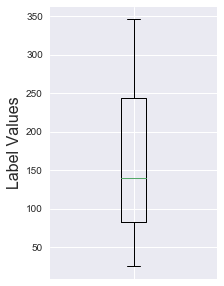

```python
# YOU ARE REQUIRED TO INSERT YOUR CODES IN THIS CELL
'''
2. Construct a box-plot for the labels.
'''

# construct a box-plot for the labels
# INSERT YOUR CODE HERE
data = (medianY, maxY, minY)

fig, ax = plt.subplots(figsize=(3, 5))
ax.boxplot(data, 0, labels=[''])
ax.set_ylabel('Label Values', fontsize=16)
ax.set_title('', fontsize=16)
```

## Part 1B. Linear Regression

You are required to apply Linear Regression to train and make predictions on the **diabetes** dataset.

**Note:** To perform a supervised learning task, we need to train the model on a training set of the input data and the correct labels, and predict the trained model on **unseen** data. Then, we use the correct labels of the **unseen** data to evaluate the performance of the model. The **unseen** dataset is called the **test set**.

**Instruction 1.4.** First you need to split the **diabetes** dataset into a training set and a test set. We will use 70% samples for training and 30% for testing. Print the number of samples in each set.

[**Total marks: 5**]

```python
# YOU ARE REQUIRED TO INSERT YOUR CODES IN THIS CELL

# first, compute the number of samples in the training set:
n_train = int(len(Y) * 0.7)

# The training set is the first n_train samples in the dataset
X_train = X[: n_train]
Y_train = Y[: n_train]# INSERT YOUR CODE HERE

# The test set is the remaining samples in the dataset
X_test = X[n_train:]# INSERT YOUR CODE HERE
Y_test = Y[n_train:]# INSERT YOUR CODE HERE

# Print the number of samples in the training set
print('The number of samples in the training set:')
# INSERT YOUR CODE HERE
print(len(X_train))

# Print the number of samples in the test set
print('The number of samples in the test set:')
# INSERT YOUR CODE HERE
print(len(X_test))
```

```
The number of samples in the training set:
309
The number of samples in the test set:
133
```

**Instruction 1.5.** Create a Linear Regression model called `lr`.

[**Total marks: 5**]

```python
# YOU ARE REQUIRED TO INSERT YOUR CODES IN THIS CELL

lr = linear_model.LinearRegression()# INSERT YOUR CODE HERE
```

**Instruction 1.6.** Fit the training data to the `lr` model.

[**Total marks: 5**]

```python
# YOU ARE REQUIRED TO INSERT YOUR CODES IN THIS CELL

# INSERT YOUR CODE HERE
lr.fit(X,Y)
```

```
LinearRegression(copy_X=True, fit_intercept=True, n_jobs=1, normalize=False)
```

**Instruction 1.7** Predict the output of the test set.

[**Total marks: 5**]

```python
Y_pred = lr.predict(X_test)# INSERT YOUR CODE HERE
print(Y_pred)
```

```
[ 138.95595037  203.86570118  172.55362727  122.95773416  213.92445645
  174.88857841  110.07169487  198.36767241  173.24601643  162.64946177
  193.31777358  191.53802295  284.13478714  279.30688474  216.0070265
  210.08517801  216.22213925  157.01489819  224.06561179  189.05840605
  103.56829281  178.70442926  111.81492124  290.99913121  182.64959461
   79.33602602   86.33287509  249.15238929  174.51439576  122.10645431
  146.27099383  170.6555544   183.50018707  163.36970989  157.03563376
  144.42617093  125.30179325  177.50072942  104.57821235  132.1746674
   95.06145678  249.9007786    86.24033937   62.00077469  156.81087903
  192.3231713   133.85292727   93.67456315  202.49458467   52.53953733
  174.82926235  196.9141296   118.06646574  235.3011088   165.09286707
  160.41863314  162.37831419  254.05718804  257.23616403  197.50578991
  184.06609359   58.62043851  194.3950396   110.77475548  142.20916765
  128.82725506  180.12844365  211.26415225  169.59711427  164.34167693
  136.2363478   174.50905908   74.67649224  246.29542114  114.14131338
  111.54358708  140.02313284  109.99647408   91.37269237  163.01389345
   75.16389857  254.05755095   53.47055785   98.48060512  100.66268306
  258.58885744  170.67482041   61.91866052  182.3042492   171.26913027
  189.19307553  187.18384852   87.12032949  148.37816611  251.35898288
  199.69712357  283.63722409   50.85577124  172.14848891  204.06179478
  174.16816194  157.93027543  150.50201654  232.9761832   121.5808709
  164.54891787  172.67742636  226.78005938  149.46967223   99.14026374
   80.43680779  140.15557121  191.90593837  199.27952034  153.63210613
  171.80130949  112.11314588  162.60650576  129.8448476   258.02898298
  100.70869427  115.87611124  122.53790409  218.17749233   60.94590955
  131.09513588  119.48417359   52.60848094  193.01802803  101.05169913
  121.22505534  211.8588945    53.44819015]
```

## Part 1C. Results and Visualization

**Note:** To evaluate the performance of a Linear Regression model, two commonly used measures are **mean absolute error** and **root mean squared error**.

**mean absolute error** is defined by:

$$mean\_absolute\_error(Y_{test}, Y_{pred}) = \frac{1}{n_{samples}}\sum_{i=1}^{n_{samples}}|y_{test}^i - y_{pred}^i|$$

**root mean squared error** is defined by:

$$root\_mean\_squared\_error(Y_{test}, Y_{pred}) = \sqrt{\frac{1}{n_{samples}}\sum_{i=1}^{n_{samples}}(y_{test}^i - y_{pred}^i)^2}$$

**Instruction 1.8.** Compute **mean absolute error** and **root mean squared error** between the correct labels and the predictions of the test set and print these two values.

[**Total marks: 8**]

**Hint:** You might need to use [Regression metrics](http://scikit-learn.org/stable/modules/model_evaluation.html#regression-metrics) from sklearn.

```python
# YOU ARE REQUIRED TO INSERT YOUR CODES IN THIS CELL

# Compute the mean absolute error between Y_test and Y_pred
# Then, print the value
# INSERT YOUR CODE HERE
mae = mean_absolute_error(Y_test, Y_pred)
print("Mean Absolute Error: {}".format(mae))

# Compute the root mean squared error between Y_test and Y_pred
# Then, print the value
# INSERT YOUR CODE HERE
mse = mean_squared_error(Y_test, Y_pred)
print("Mean Squared Error: {}".format(mse))
```

```
Mean Absolute Error: 40.45449139747527
Mean Squared Error: 2626.724102756806
```

**Note:** Visualisation is an important task. We want to see if two similar samples are predicted with two close labels. To evaluate how similar two samples are, we can compute their Euclidean distance and to evaluate how close the two labels are, we just need to compute their absolute difference.

The function below returns a Euclidean distance matrix whose element (i, j) stores the Euclidean distance between X[i] and X[j]. **You will need this function for a subsequent task.**

```python
def compute_euclidean_distance_matrix(X):
    n_samples = X.shape[0]

    # initialise the distance matrix and set all value to 0
    euclidean_distance_matrix = np.zeros([n_samples, n_samples], dtype=float)

    # compute the Euclidean distance matrix
    for i in range(n_samples):
        for j in range(n_samples):
            euclidean_distance_matrix[i, j] = np.sqrt(np.sum((X[i] - X[j]) ** 2))

    return euclidean_distance_matrix
```

**Instruction 1.9**. The following code segment is designed to visualise the Euclidean distances of the samples and the absolute differences of their predicted labels.

**Your tasks are:**

1. Construct a function that returns a matrix of absolute differences of the prediction **Y_pred** whose element (i, j) stores the absolute difference between Y_pred[i] and Y_pred[j]. (4 marks)
2. Compute the absolute difference matrix for **Y_pred** and visualise the matrix. (4 marks)
3. Compute the Euclidean distance matrix for **X_test** using compute_euclidean_distance_matrix() and visualise the matrix. (4 marks)

[**Total mark: 12**]

```python
# YOU ARE REQUIRED TO INSERT YOUR CODES IN THIS CELL
'''
1. Construct a function that returns a matrix of absolute difference of
    the prediction **Y_pred** whose element (i, j) stores
    the absolute difference between Y_pred[i] and Y_pred[j].
'''
def compute_abs_difference_matrix(Y):
    # compute the absolute difference matrix
    # and remember to return the matrix
    # INSERT YOUR CODE HERE
    n_samples = Y.shape[0]
    abs_difference_matrix = np.zeros([n_samples, n_samples], dtype=float)

    for i in range(n_samples):
        for j in range(n_samples):
            abs_difference_matrix[i, j] = np.absolute(Y_pred[i] - Y_pred[j])

    return abs_difference_matrix
```

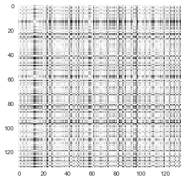

```python
# YOU ARE REQUIRED TO INSERT YOUR CODES IN THIS CELL
'''
2. Compute the absolute difference matrix for Y_pred and visualise the matrix
Hint: You might want to use imshow function.
'''

# compute the absolute difference matrix
abs_difference_matrix = compute_abs_difference_matrix(Y_pred)# INSERT YOUR CODE HERE

# visualise the matrix
# INSERT YOUR CODE HERE
fig, ax = plt.subplots(figsize=(10, 5))
ax.imshow(abs_difference_matrix)
```

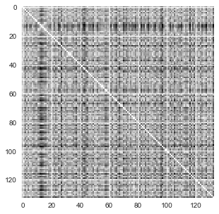

```python
# YOU ARE REQUIRED TO INSERT YOUR CODES IN THIS CELL
'''
3. Compute the Euclidean distance matrix for X_test and visualise the matrix.
Hint: You might want to use imshow function
'''

# compute the Euclidean distance matrix
Euclidean_distance_matrix = compute_euclidean_distance_matrix(X_test)# INSERT YOUR CODE HERE

# visualise the matrix
# INSERT YOUR CODE HERE
fig, ax = plt.subplots(figsize=(10, 5))
ax.imshow(Euclidean_distance_matrix)
```

# Part 2: Classification

In this part, you will be required to apply Naive Bayes algorithm for the classification task on the **breast cancer** dataset from sklearn. More about the dataset can be found [here](http://scikit-learn.org/stable/modules/generated/sklearn.datasets.load_breast_cancer.html#sklearn.datasets.load_breast_cancer).

Here, we apply Multinomial Naive Bayes for discrete features. We can construct a Multinomial Naive Bayes model by calling **naive_bayes.MultinomialNB()** from sklearn package. More about the model can be found [here](http://scikit-learn.org/stable/modules/generated/sklearn.naive_bayes.MultinomialNB.html#sklearn.naive_bayes.MultinomialNB)

## Part 2A: Load and examine the dataset

**Instruction 2.1.** Write your code to load the **breast cancer** dataset from sklearn and assign it to a variable called `cancer`.

[**Total mark: 3**]

```python
# YOU ARE REQUIRED TO INSERT YOUR CODES IN THIS CELL
'''
1. Write your code to load the dataset from sklearn and assign it to a variable called `cancer`.
'''
cancer = datasets.load_breast_cancer()# INSERT YOUR CODE HERE

print(cancer.keys())
```

```
dict_keys(['data', 'target', 'target_names', 'DESCR', 'feature_names'])
```

**Note:** The cell code below assigns the data to variable `X` and the labels to variable `Y`. Run the cell and use `X` and `Y` for later tasks.

```python
X = cancer['data']
Y = cancer['target']
```

**Instruction 2.2.** Now you need to examine the size of data. Write your code to find and print out the number of **samples** and the number of **features** in the dataset.

[**Total mark: 2**]

```python
# YOU ARE REQUIRED TO INSERT YOUR CODES IN THIS CELL
'''
2. Write your code to find and print out the number of **samples**
    and the number of **features** in the dataset.
    Using variable X.
'''
n_samples, n_features = cancer.data.shape
print('The number of samples:')
# INSERT YOUR CODE HERE
print(n_samples)
print('The number of features:')
# INSERT YOUR CODE HERE
print(n_features)
```

```
The number of samples:
569
The number of features:
30
```

**Instruction 2.3.** The following code segment is designed to do some statistics on the labels to get a brief understanding about the prediction task. This is a classication task, it is important to know the number of categories (or number of classes) in the dataset and their frequencies.

**Your tasks are:**

1. Write your code to compute and print the number of classes in the dataset. (2 marks)
2. Write your code to compute and print the number of occurrences of each class. (3 marks)

[**Total marks: 5**]

```python
# YOU ARE REQUIRED TO INSERT YOUR CODES IN THIS CELL
'''
1. Write your code to compute and print the number of classes in the dataset.
    Using variable Y.
'''

# compute and print the number of classes.
# INSERT YOUR CODE HERE
print("There are {} classes in the Dataset".format(len(cancer.target_names)))
print(cancer.target_names[0])
print(cancer.target_names[1])
```

```
There are 2 classes in the Dataset
malignant
benign
```

```python
# YOU ARE REQUIRED TO INSERT YOUR CODES IN THIS CELL
'''
2. Write your code to compute and print the number of occurrences of each class.
'''

# compute and print the number of occurrences of each class
# INSERT YOUR CODE HERE

print("There are {} occurrences of the Malignant class".format(len(cancer.target_names[0])))
print("There are {} occurrences of the Benign class".format(len(cancer.target_names[1])))
```

```
There are 9 occurrences of the Malignant class
There are 6 occurrences of the Benign class
```

## Part 2B. Classification with Naive Bayes

You are required to apply Naive Bayes to train and make predictions on the **breast cancer** dataset.

Multinomial Naive Bayes classifier is used for discrete data. The features of the breast cancer dataset are however real values. The function below discretise the features in to 0 (low), 1 (middle) and 2 (high). **Run the cell below.**

```python
def discretise(X):
    # for each feature, values smaller than 33% percentile are set by 0 (low),
    # from 33% to 67% percentile are set by 1 (middle) and other are set by 2 (high).

    n_feats = X.shape[-1]
    X_discrete = np.zeros(X.shape)

    for i in range(n_feats):
        # compute val1 and val2 as the percentile of 33% and 67%, respectively of the column i
        val1, val2 = np.percentile(X[:, i], 33), np.percentile(X[:, i], 67)

        # increase all discrete values by 1 for all values in X that larger than val1
        ids = np.where(X[:, i] > val1)[0]
        X_discrete[ids, i] += 1

        # increase all discrete values by 1 for all values in X that larger than val2
        ids = np.where(X[:, i] > val2)[0]
        X_discrete[ids, i] += 1

    return X_discrete
```

Then we call the discretise function for the feature X. **Run the cell below and your data are ready for classification.**

```python
X = discretise(X)
```

**Instruction 2.4.** Similar to **Part 1**, you need to split the dataset into a training set and a test set. We will use 70% samples for training and 30% for testing. Print the number of samples in each set.

[**Total marks: 5**]

```python
# YOU ARE REQUIRED TO INSERT YOUR CODES IN THIS CELL

# first, compute the number of samples in the training set:
n_train = int(len(Y) * 0.7)

# The training set is the first n_train samples in the dataset
X_train = X[: n_train]# INSERT YOUR CODE HERE
Y_train = Y[: n_train]# INSERT YOUR CODE HERE

# The test set is the remaining samples in the dataset
X_test = X[n_train:]# INSERT YOUR CODE HERE
Y_test = Y[n_train:]# INSERT YOUR CODE HERE

# Print the number of samples in the training set
print('The number of samples in the training set:')
# INSERT YOUR CODE HERE
print(len(X_train))
# Print the number of samples in the test set
print('The number of samples in the test set:')
# INSERT YOUR CODE HERE
print(len(X_test))
```

```
The number of samples in the training set:
398
The number of samples in the test set:
171
```

**Instruction 2.5.** Create a Multinomial Naive Bayes model called `mnb`.

[**Total marks: 5**]

```python
# YOU ARE REQUIRED TO INSERT YOUR CODES IN THIS CELL

mnb = MultinomialNB()# INSERT YOUR CODE HERE
```

**Instruction 2.6.** Fit the training data to the `mnb` model.

[**Total marks: 5**]

```python
# YOU ARE REQUIRED TO INSERT YOUR CODES IN THIS CELL

# INSERT YOUR CODE HERE
mnb.fit(X, Y)
```

```
MultinomialNB(alpha=1.0, class_prior=None, fit_prior=True)
```

**Instruction 2.7** Predict the output of the test set.

[**Total marks: 5**]

```python
Y_pred = mnb.predict(X_test) # INSERT YOUR CODE HERE
print(Y_pred)
```

```
[1 1 0 1 1 0 1 1 0 1 0 1 1 1 1 0 0 1 1 0 1 1 1 1 1 0 1 1 1 1 1 0 0 1 0 0 0
 0 1 1 1 0 1 0 0 1 0 1 0 0 0 0 1 0 1 1 0 1 1 0 0 1 0 0 0 1 0 0 0 1 0 1 1 1
 0 1 1 0 0 0 1 0 1 0 1 0 0 1 0 0 1 0 1 0 0 1 1 0 1 0 0 0 0 1 1 0 1 1 1 1 0
 0 1 0 0 0 0 1 0 0 1 1 1 0 1 1 1 1 0 0 1 1 1 1 0 0 1 0 1 1 1 1 1 1 0 0 1 1
 1 1 1 1 1 1 1 1 1 1 1 1 0 1 1 1 0 0 0 0 0 0 1]
```

## Part 2C. Results and Visualization

**Note:** To evaluate the performance of a classification task, commonly used measures are **accuracy**, **precision**, **recall** and **f1-score**.

**Instruction 2.8.** Compute the **accuracy**, **precision**, **recall** and **f1-score** of the predictions on the test set and print these values.

[**Total marks: 12**]

**Hint:** You might need to see [Classification metrics](http://scikit-learn.org/stable/modules/model_evaluation.html#classification-metrics) from sklearn.

```python
# YOU ARE REQUIRED TO INSERT YOUR CODES IN THIS CELL

# Compute and print the accuracy of predictions on the test set
# INSERT YOUR CODE HERE
print("The accuracy of the preditction is {}".format(accuracy_score(Y_test, Y_pred)))

# Compute and print the precision of predictions on the test set
# INSERT YOUR CODE HERE
print("The precision of the prediction is {}".format(precision_score(Y_test, Y_pred)))

# Compute and print the recall of predictions on the test set
# INSERT YOUR CODE HERE
print("The recall of the prediction is {}".format(recall_score(Y_test, Y_pred)))

# Compute and print the f1-score of predictions on the test set
# INSERT YOUR CODE HERE
print("The f1-score of the prediction is {}".format(f1_score(Y_test, Y_pred)))
```

```
The accuracy of the preditction is 0.7660818713450293
The precision of the prediction is 0.9791666666666666
The recall of the prediction is 0.7121212121212122
The f1-score of the prediction is 0.8245614035087719
```

**Note:** We have evaluated the performance of the classification task by different measures. Now, we want to visualise the data as well as the predicted labels. [t-SNE](http://scikit-learn.org/stable/modules/generated/sklearn.manifold.TSNE.html) is a tool to convert high-dimensional data into low-dimensional ones. To visualise the data, we can use t-SNE to reduce the data dimension to 2D.

The following function `reduce_to_2D` takes the matrix X of size (n_samples, n_features) and returns a matrix of size (n_samples, 2), which is a dimension-reduced version of X. **You will need this function for a subsequent task**.

```python
def reduce_to_2D(X):
    tsne = TSNE(n_components=2, random_state=1)
    new_X = tsne.fit_transform(X)
    return new_X
```

**Instruction 2.9**. Visualisation.

**Your tasks are:**

1. Create a variable named `X_test_2D` that is the dimension-reduced version of X_test using function `reduce_to_2D`. (4 marks)
2. Visualise `X_test_2D` using scatter() with the colors being the corresponding predicted labels. (4 marks)

[**Total mark: 8**]

```python
# YOU ARE REQUIRED TO INSERT YOUR CODES IN THIS CELL
'''
1. Create a variable named `X_test_2D`
    that is the dimension-reduced version of X_test using function `reduce_to_2D`.
'''

# INSERT YOUR CODE HERE
X_test_2D = reduce_to_2D(X_test)
```

[figure not shown]

```python
# YOU ARE REQUIRED TO INSERT YOUR CODES IN THIS CELL
'''
2. Visualise `X_test_2D` by scatters with the colors being the corresponding predicted labels.
'''

# INSERT YOUR CODE HERE
colour = 'red', 'blue'
fig, ax = plt.subplots()
ax.scatter(X_test_2D[:, 0], X_test_2D[:, 1], label='Malignant', s=50, c=colour)
plotTitle = plt.title('Dimension Reduced Scatter Plot', fontsize = 15)
x_axis_tick = plt.xticks([])
y_axis_tick = plt.yticks([])
red_patch = mpatches.Patch(color='red', label='Malignant')
blue_patch = mpatches.Patch(color='blue', label='Benign')

plt.legend(handles=[red_patch, blue_patch])
```